# Writing R Packages 101

Oleksii Dubovyk

2025-11-05

# 1 Resources

- [Official R Team documentation](https://cran.r-project.org/doc/manuals/r-release/R-exts.html) (very dry, vague, and you will have to Google everything if you start with that one; not recommended, but yet, it’s the official standard)
- Wickham’s and Bryan’s “[R Packages](https://r-pkgs.org/)” (very detailed, but quite helpful)
- If unsure – always Google; somebody had the same issue on Stack Overlflow five years ago
- ChatGPT / Gemini / etc. are not a viable resource (boo AI)

# 2 Sharing or getting new packages

- **CRAN** is a default repository. However, CRAN is very strict and your package submission is likely to be rejected after review due to redundancy, code inconsistency, random issue with LATEX compiling vignettes pdf… ([More on Reddit](https://www.reddit.com/r/Rlanguage/comments/1io77va/is_cran_holding_r_back_ari_lamstein))
- **GitHub**: you can use Git for version control and – whoa – let people download intermediate and release-ready versions directly. Highly recommended if the package is a team effort. If you want to install a package and it’s not on CRAN but exists on GitHub, it’s easy to do with devtools package:

```r
if(!require("devtools")) install.packages("devtools")
devtools::install_github("<username>/<packagename>")
```

E.g., if you want to install the package from the URL https://github.com/OleksiiDubovyk/FilterABM, the syntax would be

```r
devtools::install_github("OleksiiDubovyk/FilterABM")
```

- **Old school**: create an archive file of your package and send it to your friend on a floppy disk. RStudio has an option to install a package from an archive (`Tools` > `Install packages...` > `Install from:` change to “Package Archive File (.tar.gz)”). This option can be helpful when a package is discontinued and removed from CRAN, but you can find the archive image on Wayback Machine.

# 3 Why R package?

- Consistency. Your package is a whole. To build a new package, all objects in the package must be consistent. If you changed one function but forgot to align the input of another function which depended on it, the package wouldn’t build until you fix it.
- Documentation. You write a function, now you have to write the help info for it explaining every parameter format and what this function does and what the output is. Very helpful when you get back to your code two years later and don’t remember what it was supposed to do.
- Standard organization. Everything is tidy and in its own folder.
- It’s a cool skill.

# 4 Typical R package structure

# 5 Before you begin developing

- Using your local machine is recommended. HPC can be finicky. Be sure to install R and RStudio on your computer:
  - R can be installed from here: https://cloud.r-project.org/
  - RStudio can be installed from here: https://posit.co/download/rstudio-desktop/
- You will need the following packages, but don’t install them yet:
  - `devtools`
  - `usethis`
  - `testthat`
  - `roxygen2`
  - `renv`
  - `tidyverse`

# 6 Getting started

## 6.1 Create a “New Project” in RStudio (top right)

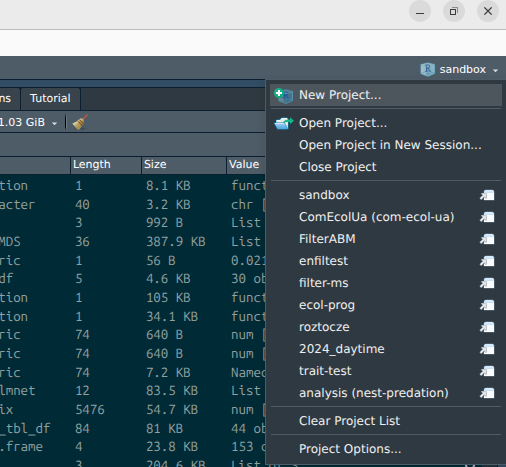

## 6.2 Click “New Directory”

[figure not shown]

## 6.3 Click “R Package”

[figure not shown]

## 6.4 Name your package

[figure not shown]

Make sure to use a meaningful path (please no iClouds or OneDrives, do it within your real file system).

Double check that you click

- (✓) `Create a git repository`, and
- (✓) `Use renv with this project`

So what is **renv**? Everybody’s system is different: you probably have installed some packages I don’t have on my computer. All packages are saved somewhere in your file system, and the location is likely different on my computer. How do we make sure that such idiosyncrasies don’t interfere with package development? `renv` forces us to ignore all packages currently installed on your system and creates an isolated environment for the R project where you develop your new package. If, for example, you plan to use `tidyverse` in your package and you currently have it installed on your machine, with `renv` enabled you would need to install `tidyverse` again within the contained environment – and `renv` will remember it.

## 6.5 Install packages

Since `renv` ignores everything already installed on your computer, we need to install all the packages we will need for developing. We could do it by hand (in RStudio: `Tools` > `Install Packages...`), or, we can do it in a fancy way (most likely, R will also ask for a bunch of dependencies; follow the prompts):

```r
pink_elephant <- c("devtools", "usethis", "testthat", "roxygen2", "renv", "tidyverse")
for (pkg in pink_elephant) renv::install(pkg)
```

If you get errors that some packages can’t be installed, try the following:

- Install the package that gives your trouble through `Tools` > `Install packages...`
- If not, do it in the console like

```r
install.packages(“<trouble-package>”, dependencies = T)
```

and watch for messages to figure out what dependencies can’t be installed; try to install them manually in the same way:

```r
install.packages(“<dependency>”, dependencies = T)
```

- If that doesn’t work, email Oleksii at odubo001@odu.edu

## 6.6 Delete `NAMESPACE` file

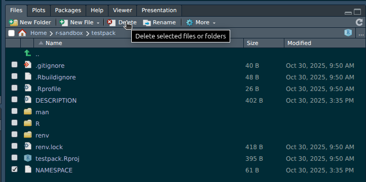

# 7 Writing the package

Imagine we want to create a package with functions to estimate different indices of community diversity. All of them will take the same data format: vectors of species abundances. Let’s consider three metrics: species richness, Shannon index, and Simpson index, all of which are very common across disciplines.

Let’s do everything step by step.

## 7.1 Create empty R script file

Create an empty R script in which we will write our new function. You can do so by calling

```r
usethis::use_r("sprich")
```

## 7.2 Write new function

The previous step opens a new script which we can modify. Let’s write our new function:

```r
sprich <- function(n){
    # delete all non-positive values
    n <- n[n>0]
    # estimate species richness
    return(length(n))
}
```

## 7.3 Initialize documentation

Now we should write documentation for this function. Put your cursor inside of the function body (i.e., anywhere between “{” and “}”) and go to `Code` > `Insert Roxygen Skeleton`:

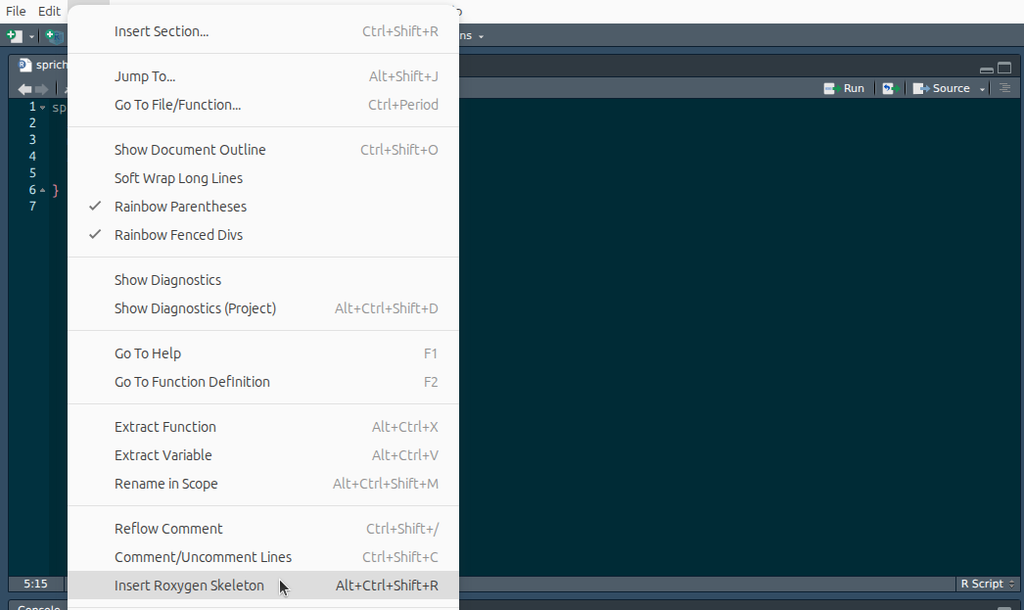

## 7.4 Write documentation

```r
#' Title
#'
#' @param n
#'
#' @returns
#' @export
#'
#' @examples
sprich <- function(n){
  # delete all non-positive values
  n <- n[n>0]
  # estimate species richness
  return(length(n))
}
```

This is the step where we should give our function a name, some brief description, explain to the future users what the input (parameters) should look like, etc. Roxygen will only look at the lines of the script that are commented out with the special operator `#'` as opposed to a usual comment `#`.

Sections of the documentation are defined with operator `@`. Everything that goes into this section should be typed in the same line or below it. There are many possible sections but here are some of the common ones:

- `@description` should be followed with a paragraph or several paragraphs describing your function. You can embed LATEX equations with `\eqn{<your LATEX code here>}`.
- `@param <function argument>` is used to describe the format of function input; note that your package will fail to build if any of your functions have an argument for which there’s no description (it’s tricky if your function has an argument `...` – you must formally describe it as, e.g., `#' @param ... Additional arguments`).
- `@returns` should describe the output of your function (e.g., variable type, format, etc.)
- `@importFrom <package> <function>` is very important if your function uses any external functions from outside of the base R syntax. It will tell the NAMESPACE which functions should be imported for your package to work properly.
- `@export` will tell the NAMESPACE to remember your new function; without it, the script for your function will be there but it will not be a part of the package.
- `@examples` will provide code snippets to illustrate your function in action; this can include multiple lines of code below the section

In our case, the fully annotated script will look something like this:

```r
#' Species richness
#'
#' @description
#' Counts the number of species with non-zero abundance in the sample.
#'
#' @param n numeric vector with species abundances where each element corresponds to abundance of one species.
#'
#' @returns Numeric, species richness.
#'
#' @export
#'
#' @examples
#' x = c(0, 0, 1, 2, 3)
#' sprich(x)
sprich <- function(n){
  # delete all non-positive values
  n <- n[n>0]
  # estimate species richness
  return(length(n))
}
```

## 7.5 Save documentation

Save the script. Write the documentation out by typing

```r
devtools::document()
```

Check the `NAMESPACE` file. Since we deliberately deleted it before, now the `NAMESPACE` is being generated by `roxygen2` using all the stuff you wrote with `#'` and should not be edited by hand. This file will keep track of all imports and exports needed for the package to function properly.

## 7.6 Load package

Load the latest iteration of your package with

```r
devtools::load_all()
```

This will put all the functions you wrote so far into your package environment.

## 7.7 Setup testing

Now, it’s a good idea to write some tests for your package. Tests will ensure that your function return what you want them to return, even when you make some changes during the development.

To setup your testing infrastructure, call the following (**you only need to do it once**):

```r
usethis::use_testthat(3)
```

## 7.8 Write test

To write a new test, call

```r
usethis::use_test("estimation")
```

This will create a new test (which is just an R script) called “estimation.”

Say, we want to write a test for the species richness function: for a community with species abundances $\{0, 0, 1, 2, 3\}$ there are only three species with abundance $>0$, thus we expect species richness to equal to $3$. Thus, our test script will look like this:

```r
test_that("species richness correct", {
  expect_equal(sprich(c(0, 0, 1, 2, 3)), 3)
})
```

## 7.9 Run tests

You can run all test files by calling

```r
devtools::test()
```

## 7.10 Build package

Now, we can try to build the package as a whole. For that, in RStudio, go to the `Build` tab (upper right corner) and click `Check`. If your package is built with no errors, you should now be able to find the archive file with your package in your parent directory (it should look something like “testpack_0.1.0.tar.gz”).

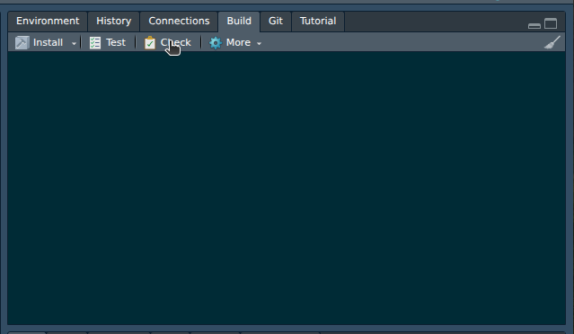

Note: if you followed this manual with no deviations, you should get a warning on build that your license is bad.

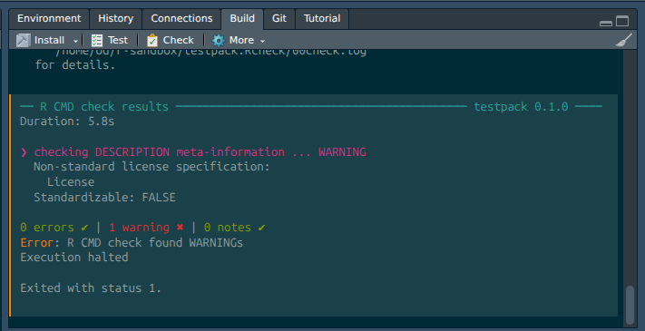

This is because we didn’t edit the `DESCRIPTION` file. Go ahead and fill it out. You will need to indicate the license type you want to use (e.g., MIT + file LICENSE) and then you will probably need to create a file with a name `LICENSE` which contains these two lines:

```
YEAR: <current year>
COPYRIGHT HOLDER: <author(s) name(s)>
```

# 8 Repeat for new functions

Follow the steps above (except 7.7) to write two new functions for Shannon and Simpson diversity. For a community of $\{1, 2, …, i, …, S–1, S\}$ species, we define species’ $i$ abundance as $n_i$. If we denote the total abundance of all species as $N = \sum_{i=1}^S n_i$, then species’ relative abundance can be calculated as $p_i = \frac{n_i}{N}$.

The formulas for the diversity indices are:

- Shannon $H = - \sum \limits_{i=1}^S [p_i \cdot \ln(p_i)]$,
- Simpson $D = \left( \frac{N}{N-1} \right) \cdot \left( 1 - \sum \limits_{i=1}^S p_i^2 \right)$.